# First look at data and random forests

Szymon Makulec

2024-11-18

Basic statistics

```r
library(tidyverse)
library(DT)

summary_data <- summary(data)
summary_df <- as.data.frame(t(summary_data))
datatable(summary_df,
          options = list(pageLength = 6, autoWidth = TRUE), rownames = FALSE )
```

| Var1 | Var2 | Freq |
| --- | --- | --- |
| age |  | Min. :0.0000 |
| income |  | Min. :0.0000 |
| credit_history |  | brak historii :2375 |
| overdue_payments |  | brak opóźnień:5591 |
| years_in_job |  | Min. :0.0000 |
| owns_property |  | 0:3405 |
| assets_value |  | Min. :0.0000 |
| other_loans |  | 0:5470 |
| credit_risk |  | 0:8717 |
| active_loans_0 |  | Min. :0.00 |

[output cut: 170 more lines]

Dane nie zawierają żadnych anomalii ani nierealistycznych wartości, co zapewnia integralność zbioru danych. W naszych danych tylko 294/8717 osób jest klasyfikowanych jako wysokie ryzyko, więc musimy szczególnie skupić się na tej małej grupie.

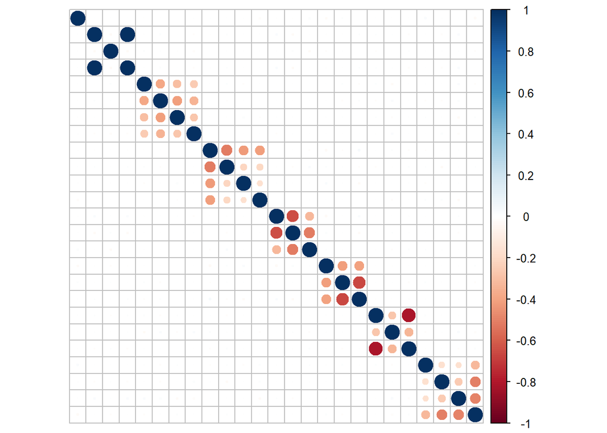

```r
library(corrplot)
correlation_matrix <- cor(data[, sapply(data, is.numeric)])
corrplot(correlation_matrix, method = "circle", tl.pos = "n" )
```

Na początku wydaje się, że ryzyko kredytowe nie jest znacząco skorelowane z żadnym z naszych predyktorów, ale przetestujemy to. Widzimy silne dodatnie i ujemne korelacje między niektórymi predyktorami, ale na razie nas to nie niepokoi, ponieważ możemy użyć lasu losowego, który jest odporny na autokorelację predyktorów.

Dzielimy dane na numeryczne i kategoryczne

```r
data_num <- data %>% select_if(is.numeric)
data_fac <- data %>% select_if(is.factor)
```

Wizualizacje dla wartości numerycznych

```r
library(caret)
```

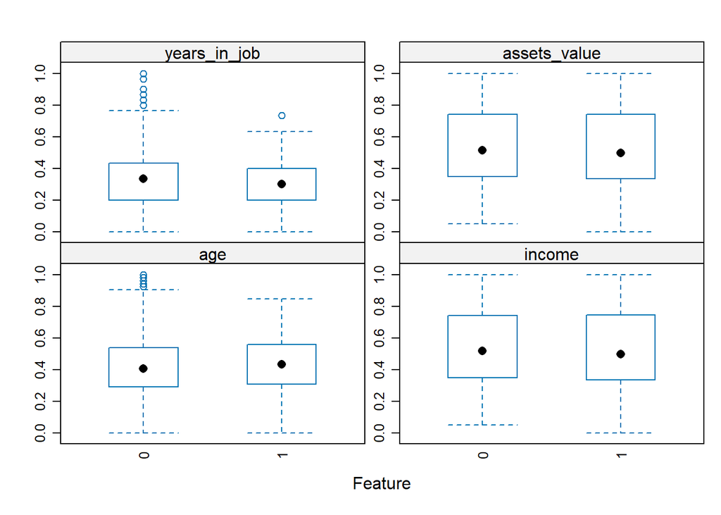

```r
featurePlot(x = data_num[,c(1:4)],
            y = data$credit_risk,
            plot = "box",
            scales = list( y = list(relation="free"),
                           x = list(rot=90) ),
            layout = c(2,2))
```

Widać, że największy wpływ na credit_risk mają age i years_in_job

Tabele wpływów zmiennych typu factor ( niektóre błędnie trafiły do numerycznych) na credit risk. Należy powiedzieć, że 0 i 1 po lewej stronie każdej tabeli informują nas o ryzyku kredytowym, a 0 i 1 na górze oznaczają obecność danej zmiennej.

```r
for ( i in 1 : ncol(data_fac) ){
  print(names(data_fac[i]))
  print(prop.table(table(data$credit_risk, data_fac[[i]])))
}
```

```
## [1] "credit_history"
##
##     brak historii dobra historia
##   0   0.255798469    0.711574742
##   1   0.007768283    0.024858506
## [1] "overdue_payments"
##
##     brak opóźnień  opóźnienia
##   0   0.610476085 0.356897126
##   1   0.009987793 0.022638997
## [1] "owns_property"
##
##              0          1
##   0 0.36577516 0.60159805
##   1 0.01209633 0.02053046
## [1] "other_loans"
##
##              0          1
##   0 0.58794806 0.37942515
##   1 0.01908778 0.01353901
## [1] "credit_risk"
##
##              0          1
##   0 0.96737321 0.00000000
##   1 0.00000000 0.03262679
```

```r
for ( i in 5 : ncol(data_num) ){
  print(names(data_num[i]))
  print(prop.table(table(data$credit_risk, data_num[[i]])))
}
```

```
## [1] "active_loans_0"
##
##               0           1
##   0 0.750305183 0.217068028
##   1 0.029741427 0.002885362
## [1] "active_loans_1"
##
##               0           1
##   0 0.632782155 0.334591055
##   1 0.027743869 0.004882921
## [1] "active_loans_2"
##
##              0          1
##   0 0.71956498 0.24780823
##   1 0.02796582 0.00466097
```

[output cut: 90 more lines]

(Moim zdaniem) Najważniejsze zmienne objaśniające : credit_history, overdue_payments, owns_property, other_loans, active_loans_0, active_loans_1, active_loans_2, children_1, children_2, children_3, education_podstawowe, education_wyższe, city_duże, city_małe, marital_status_rozwiedziony_rozwiedziona

Ustalenie podziału danych

```r
minority <- data[data$credit_risk == "1", ]
majority <- data[data$credit_risk == "0", ]

minority_oversampled <- minority[sample(1:nrow(minority),
                                        size = nrow(majority),
                                        replace = TRUE), ]
df_balanced <- rbind(majority, minority_oversampled)
```

```r
podzial <- createDataPartition(
  y=df_balanced$credit_risk,
  times = 1,
  p=0.8,
  list=F
)
```

```r
trening <- df_balanced[podzial,]
test <- df_balanced[-podzial,]

head(trening[trening$credit_risk==1,])
```

```
##            age    income credit_history overdue_payments years_in_job
## 8922 0.4807692 0.3613376 dobra historia       opóźnienia    0.5333333
## 5534 0.4615385 0.1991956 dobra historia    brak opóźnień    0.3333333
## 7067 0.3461538 0.5486711 dobra historia    brak opóźnień    0.4333333
## 4436 0.5384615 1.0000000 dobra historia       opóźnienia    0.3666667
## 866  0.3461538 0.5319583 dobra historia    brak opóźnień    0.3000000
## 1137 0.6346154 0.2834937 dobra historia       opóźnienia    0.4666667
##      owns_property assets_value other_loans credit_risk active_loans_0
## 8922             1    0.3613376           0           1              0
## 5534             1    0.1991956           0           1              0
## 7067             0    0.5486711           1           1              0
## 4436             1    1.0000000           1           1              0
## 866              1    0.5319583           1           1              0
## 1137             1    0.2834937           1           1              1
##      active_loans_1 active_loans_2 active_loans_3 children_0 children_1
```

[output cut: 48 more lines]

```r
head(test[test$credit_risk==1,])
```

```
##              age    income credit_history overdue_payments years_in_job
## 5695   0.7500000 0.4313821 dobra historia    brak opóźnień   0.16666667
## 8406   0.0000000 0.8759579 dobra historia    brak opóźnień   0.20000000
## 1264   0.2307692 0.2151204 dobra historia       opóźnienia   0.50000000
## 9853   0.5384615 0.0259525  brak historii       opóźnienia   0.30000000
## 2119   0.0000000 0.3224904  brak historii       opóźnienia   0.36666667
## 9675.1 0.5384615 0.0000000 dobra historia       opóźnienia   0.06666667
##        owns_property assets_value other_loans credit_risk active_loans_0
## 5695               0    0.4313821           0           1              0
## 8406               1    0.8759579           1           1              1
## 1264               0    0.2151204           0           1              0
## 9853               1    0.0259525           0           1              0
## 2119               1    0.3224904           0           1              0
## 9675.1             1    0.0000000           1           1              0
##        active_loans_1 active_loans_2 active_loans_3 children_0 children_1
```

[output cut: 48 more lines]

Zarówno w zbiorze testowym jak i treningowym mamy sytuacje typu 0 oraz 1. Szczególnie w zbiorze treningowym interesuje nas żeby model nie przeuczył się w stronę 0 więc sztucznie tworzymy nowe obserwacje.

Trenujemy lasu losowe

```r
library(randomForest)
las <- randomForest(credit_risk~., trening)
las$type
```

```
## [1] "classification"
```

```r
las$importance
```

```
##                                          MeanDecreaseGini
## age                                             636.95418
## income                                          666.40461
## credit_history                                  106.00768
## overdue_payments                                826.07715
## years_in_job                                    574.65311
## owns_property                                   132.13005
## assets_value                                    653.69905
## other_loans                                     119.66370
## active_loans_0                                  184.95923
## active_loans_1                                  244.38381
## active_loans_2                                  145.72945
## active_loans_3                                 1032.08416
## children_0                                      101.48783
## children_1                                       83.82432
## children_2                                       83.03046
## children_3                                       79.25452
## education_podstawowe                             91.93316
## education_średnie                                87.45979
## education_wyższe                                 71.93583
## city_duże                                        79.52565
## city_małe                                        89.86240
## city_średnie                                     94.00069
## marital_status_kawaler_panna                     88.48692
## marital_status_rozwiedziony_rozwiedziona         69.88287
## marital_status_żonaty_zamężna                    90.25125
## employment_type_brak                             67.93278
## employment_type_określona                        88.88567
## employment_type_samozatrudnienie                 96.12895
## employment_type_stała                            93.20977
```

```r
las$ntree
```

```
## [1] 500
```

```r
las
```

```
##
## Call:
##  randomForest(formula = credit_risk ~ ., data = trening)
##                Type of random forest: classification
##                      Number of trees: 500
## No. of variables tried at each split: 5
##
##         OOB estimate of  error rate: 0.27%
## Confusion matrix:
##      0    1 class.error
## 0 6936   38  0.00544881
## 1    0 6974  0.00000000
```

```r
saveRDS(las, "model_las.rds")
```

```r
las <- readRDS("model_las.rds")
```

Predykcje dla zbioru testowego

```r
pr <- predict(las, test)
confusionMatrix(pr, test$credit_risk)
```

```
## Confusion Matrix and Statistics
##
##           Reference
## Prediction    0    1
##          0 1735    0
##          1    8 1743
##
##                Accuracy : 0.9977
##                  95% CI : (0.9955, 0.999)
##     No Information Rate : 0.5
##     P-Value [Acc > NIR] : < 2e-16
##
##                   Kappa : 0.9954
##
##  Mcnemar's Test P-Value : 0.01333
##
##             Sensitivity : 0.9954
##             Specificity : 1.0000
##          Pos Pred Value : 1.0000
##          Neg Pred Value : 0.9954
##              Prevalence : 0.5000
##          Detection Rate : 0.4977
##    Detection Prevalence : 0.4977
##       Balanced Accuracy : 0.9977
##
##        'Positive' Class : 0
##
```

Jak na pierwszy las losowy to tragedii nie ma, ale mogłoby być lepiej.

Próbujemy stworzyć las inną metodą

```r
lass <- randomForest(credit_risk~., trening, ntree = 100)
lass
```

```
##
## Call:
##  randomForest(formula = credit_risk ~ ., data = trening, ntree = 100)
##                Type of random forest: classification
##                      Number of trees: 100
## No. of variables tried at each split: 5
##
##         OOB estimate of  error rate: 0.4%
## Confusion matrix:
##      0    1 class.error
## 0 6918   56 0.008029825
## 1    0 6974 0.000000000
```

```r
saveRDS(lass, "model_lass.rds")
```

```r
lass <- readRDS("model_lass.rds")
```

```r
prr <- predict(lass, test)
confusionMatrix(prr, test$credit_risk)
```

```
## Confusion Matrix and Statistics
##
##           Reference
## Prediction    0    1
##          0 1732    0
##          1   11 1743
##
##                Accuracy : 0.9968
##                  95% CI : (0.9944, 0.9984)
##     No Information Rate : 0.5
##     P-Value [Acc > NIR] : < 2.2e-16
##
##                   Kappa : 0.9937
##
##  Mcnemar's Test P-Value : 0.002569
##
##             Sensitivity : 0.9937
##             Specificity : 1.0000
##          Pos Pred Value : 1.0000
##          Neg Pred Value : 0.9937
##              Prevalence : 0.5000
##          Detection Rate : 0.4968
##    Detection Prevalence : 0.4968
##       Balanced Accuracy : 0.9968
##
##        'Positive' Class : 0
##
```